# Appendix B. Cumulative impacts of mining and wind power development on reindeer: landscape-scale habitat selection analysis (HSA)

Abstract

Here we provide supplementary information regarding the landscape-scale (2nd order) assessment of reindeer selection for grazing sites in the Malå reindeer herding community, Sweden, under the presence of mining and wind power development, for the three snow-free seasons: calving, summer, and autumn. Taking into account different zone of influence (ZOI) radii for mining, different ZOI types (density vs. nearest) and radii for wind turbines, and different scales for the topographic position index, we fitted a total of 294 models for each season and compared them through model selection procedures. Here we present, for each season: (i) the setup of the habitat selection models; (ii) the best-ranged habitat selection models; (iii) the model selection tables comparing the structure and likelihood of the different models; (iv) the tables of coefficients; (v) figures illustrating the impacts of mining and wind turbines; (vi) maps with the predicted habitat suitability and GPS data across the three wind power development phases.

# 1 Text B1: Statistical modeling of the HSA

As described in the main text, the landscape-scale HSA followed a habitat selection function setup. The overall model structure we fitted was the following:

```r
base_formula <- case_ ~
  # habitat selection
  scale(dem) + I(scale(dem)^2) + scale(slope) + cos_aspect +
  scale(sos) +
  log(power_lines_dist+1) + log(priv_road_dist+1) + log(public_road_dist+1) +
  log(trails_dist+1) +
  log(house_dist+1) +
  # mining habitat selection
  scale(mining_Krist_nearestXXX) +
  # wind habitat selection
  wf_name +
  landcover*phase*scale(wind_turbines_ZZZ) +
  # tpi habitat selection
  tpi_scale_TTT
```

where the terms are:

- `case_`: our response variable (0/1);
- `dem`: elevation, we include a linear and a quadratic term;
- `slope`: slope;
- `cos_aspect`: cosine of the aspect;
- `tpi_scale_TTT`: topographic position index (TPI) computed at a certain scale, classified in 6 levels: flat, lower slope, medium slope, upper slope, ridge, valley;
- `sos`: start of season (used for calving and summer), replaced by `eos`, end of season, for autumn;
- `phase`: wind power development phase, with 3 categories: before construction, during construction, operation;
- `wf_name`: name of the wind power plant closest to each point, with four categories, added as a fixed effect to control for differential effects close to the Åmliden wind park, which lies along a large fenced area;
- `landcover`: land cover, with 5 categories: deciduous forest, coniferous forest, open areas, mires, and anthropogenic areas;
- `log(public_road_dist+1)`, `log(priv_road_dist+1)`, `log(trails_dist+1)`, `log(house_dist+1)`, `log(power_lines_dist+1)`: logarithm of the distance to the nearest infrastructure for public roads, private roads, trails, houses, and power lines;
- `mining_Krist_nearestXXX`: ZOI (exponential decay distance) of the mine, computed considering a certain ZOI radius;
- `wind_turbines_ZZZ`: ZOI of wind turbines (considering either the density or the nearest infrastructure only), computed considering a certain ZOI radius.

The terms `XXX`, `ZZZ`, and `TTT` in the model structure above represent scales or variables that varied across models fitted. To evaluate the most likely ZOI for the mine and the wind turbines, whether there was a cumulative impact of multiple wind power plants, and at which scale the TPI most affected reindeer habitat selection, we replaced these variables in the model structure above using each possible combination of ZOI radii and type (cumulative vs. nearest; Fig. B1) for wind power and the different ZOI radii for the mine, together with different scales for the TPI. Models were compared through Akaike information criterion (AIC), as described in the main text. The scales included were:

- Mining (`XXX`): 100 m, 250 m, 500 m, 1 km, 2.5 km, 5 km, 10 km.
- Wind turbines (`ZZZ`): density of turbines or distance to the nearest turbine, with ZOI radii 100 m, 250 m, 500 m, 1 km, 2.5 km, 5 km, 10 km.
- TPI: 150 m, 250 m, 510 m.

All fixed terms are shared across models, and only the mine ZOI, the wind ZOI type and radius, and TPI scale varied. Consequently, all models had the same number of parameters (n = 49). This combination of possible variables resulted in a total of 294 models tested and compared for each season. Models were built with data of all individuals pooled.

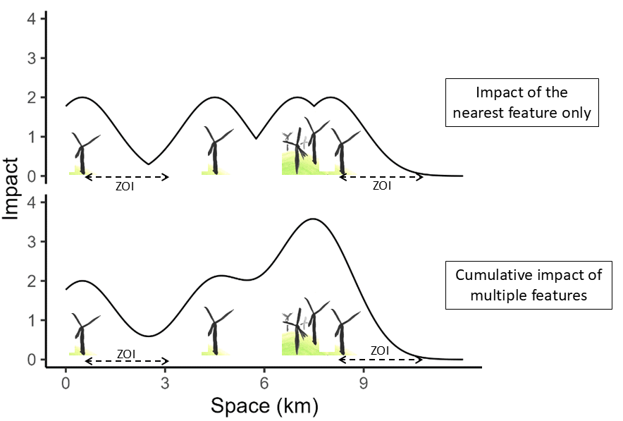

Figure B1. Illustration of two types of measures used to represent the influence of wind turbines in our study. The upper row shows the expected impact if we consider the effect of the nearest wind turbine only, which is similar whether one gets closer to one isolated turbine or a whole wind park. The bottom row shows the density of wind turbines, which captures the cumulative impact of multiple wind turbines and is larger when one gets closer to a wind park than to an isolated wind turbine. These two types of variables were used as predictors in the statistical models to estimate whether there were cumulative impacts of features of the same type.

# 2 Text B2: Best-ranked habitat selection models

This is the structure of the best-ranked HSA model selected for each season.

Summary of best ranked models:

- **Calving. Impact of the nearest wind turbine, ZOI radius = 5 km; ZOI of the mine with radius 10 km:**  
  case_ ~ scale(dem) + I(scale(dem)^2) + scale(slope) + cos_aspect + scale(sos) + log(power_lines_dist + 1) + log(priv_road_dist + 1) + log(public_road_dist + 1) + log(trails_dist + 1) + log(house_dist + 1) + wf_name + tpi_cat_s150m + scale(mining_Krist_nearest10000) + landcover_cc_grouped + phase + scale(wind_turbines_nearest5000) + landcover_cc_grouped:phase + landcover_cc_grouped:scale(wind_turbines_nearest5000) + phase:scale(wind_turbines_nearest5000) + landcover_cc_grouped:phase:scale(wind_turbines_nearest5000)
- **Summer. Cumulative impact of wind turbines, ZOI radius = 10 km; ZOI of the mine with radius 10 km:**  
  case_ ~ scale(dem) + I(scale(dem)^2) + scale(slope) + cos_aspect + scale(sos) + log(power_lines_dist + 1) + log(priv_road_dist + 1) + log(public_road_dist + 1) + log(trails_dist + 1) + log(house_dist + 1) + wf_name + tpi_cat_s510m + scale(mining_Krist_nearest10000) + landcover_cc_grouped + phase + scale(wind_turbines_cumulative10000) + landcover_cc_grouped:phase + landcover_cc_grouped:scale(wind_turbines_cumulative10000) + phase:scale(wind_turbines_cumulative10000) + landcover_cc_grouped:phase:scale(wind_turbines_cumulative10000)
- **Autumn. Impact of the nearest wind turbine, ZOI radius = 10 km; ZOI of the mine with radius 10 km:**  
  case_ ~ scale(dem) + I(scale(dem)^2) + scale(slope) + cos_aspect + scale(eos) + log(power_lines_dist + 1) + log(priv_road_dist + 1) + log(public_road_dist + 1) + log(trails_dist + 1) + log(house_dist + 1) + wf_name + tpi_cat_s510m + scale(mining_Krist_nearest10000) + landcover_cc_grouped + phase + scale(wind_turbines_nearest10000) + landcover_cc_grouped:phase + landcover_cc_grouped:scale(wind_turbines_nearest10000) + phase:scale(wind_turbines_nearest10000) + landcover_cc_grouped:phase:scale(wind_turbines_nearest10000)

# 3 Table B1: Model selection table in calving

|  | Mining ZOI radius | Wind turbine ZOI radius | TPI | logLik | AIC | dAIC | Akaike weights | Cumulative Akaike weights | formula |
| --- | --- | --- | --- | --- | --- | --- | --- | --- | --- |
| 1 | 10000 | nearest5000 | 150m | -318176.9 | 636451.83 | 0 | 1 | 1 | case_ ~ scale(dem) + I(scale(dem)^2) + scale(slope) + cos_aspect + scale(sos) + log(power_lines_dist + 1) + log(priv_road_dist + 1) + log(public_road_dist + 1) + log(trails_dist + 1) + log(house_dist … |
| 2 | 10000 | nearest10000 | 150m | -318218.7 | 636535.49 | 83.66 | &lt; 0.0001 | 1 | case_ ~ scale(dem) + I(scale(dem)^2) + scale(slope) + cos_aspect + scale(sos) + log(power_lines_dist + 1) + log(priv_road_dist + 1) + log(public_road_dist + 1) + log(trails_dist + 1) + log(house_dist … |
| 3 | 10000 | nearest5000 | 250m | -318219.4 | 636536.89 | 85.05 | &lt; 0.0001 | 1 | case_ ~ scale(dem) + I(scale(dem)^2) + scale(slope) + cos_aspect + scale(sos) + log(power_lines_dist + 1) + log(priv_road_dist + 1) + log(public_road_dist + 1) + log(trails_dist + 1) + log(house_dist … |
| 4 | 10000 | nearest2500 | 150m | -318236.2 | 636570.44 | 118.61 | &lt; 0.0001 | 1 | case_ ~ scale(dem) + I(scale(dem)^2) + scale(slope) + cos_aspect + scale(sos) + log(power_lines_dist + 1) + log(priv_road_dist + 1) + log(public_road_dist + 1) + log(trails_dist + 1) + log(house_dist … |
| 5 | 10000 | nearest10000 | 250m | -318258.2 | 636614.36 | 162.52 | &lt; 0.0001 | 1 | case_ ~ scale(dem) + I(scale(dem)^2) + scale(slope) + cos_aspect + scale(sos) + log(power_lines_dist + 1) + log(priv_road_dist + 1) + log(public_road_dist + 1) + log(trails_dist + 1) + log(house_dist … |
| 6 | 10000 | cumulative5000 | 150m | -318262.8 | 636623.66 | 171.82 | &lt; 0.0001 | 1 | case_ ~ scale(dem) + I(scale(dem)^2) + scale(slope) + cos_aspect + scale(sos) + log(power_lines_dist + 1) + log(priv_road_dist + 1) + log(public_road_dist + 1) + log(trails_dist + 1) + log(house_dist … |
| 7 | 10000 | nearest5000 | 510m | -318275.8 | 636649.69 | 197.86 | &lt; 0.0001 | 1 | case_ ~ scale(dem) + I(scale(dem)^2) + scale(slope) + cos_aspect + scale(sos) + log(power_lines_dist + 1) + log(priv_road_dist + 1) + log(public_road_dist + 1) + log(trails_dist + 1) + log(house_dist … |
| 8 | 10000 | nearest2500 | 250m | -318280.4 | 636658.89 | 207.06 | &lt; 0.0001 | 1 | case_ ~ scale(dem) + I(scale(dem)^2) + scale(slope) + cos_aspect + scale(sos) + log(power_lines_dist + 1) + log(priv_road_dist + 1) + log(public_road_dist + 1) + log(trails_dist + 1) + log(house_dist … |
| 9 | 10000 | cumulative2500 | 150m | -318296.9 | 636691.87 | 240.03 | &lt; 0.0001 | 1 | case_ ~ scale(dem) + I(scale(dem)^2) + scale(slope) + cos_aspect + scale(sos) + log(power_lines_dist + 1) + log(priv_road_dist + 1) + log(public_road_dist + 1) + log(trails_dist + 1) + log(house_dist … |
| 10 | 10000 | cumulative10000 | 150m | -318302.9 | 636703.79 | 251.96 | &lt; 0.0001 | 1 | case_ ~ scale(dem) + I(scale(dem)^2) + scale(slope) + cos_aspect + scale(sos) + log(power_lines_dist + 1) + log(priv_road_dist + 1) + log(public_road_dist + 1) + log(trails_dist + 1) + log(house_dist … |

[output cut: 284 more lines]

Table B1. Table of model selection for the HSA models for calving. Columns are zone of influence (ZOI) radius for mining and wind turbines, scale for the topographic position index (TPI), the log Likehood and AIC of the model, dAIC of each model in relation to the most parsimonious model, Akaike weights, cumulative Akaike weights, and the formula with each model’s structure.

# 4 Table B2: Model selection table in summer

|  | Mining ZOI radius | Wind turbine ZOI radius | TPI | logLik | AIC | dAIC | Akaike weights | Cumulative Akaike weights | formula |
| --- | --- | --- | --- | --- | --- | --- | --- | --- | --- |
| 1 | 10000 | cumulative10000 | 510m | -342879.6 | 685857.23 | 0 | 1 | 1 | case_ ~ scale(dem) + I(scale(dem)^2) + scale(slope) + cos_aspect + scale(sos) + log(power_lines_dist + 1) + log(priv_road_dist + 1) + log(public_road_dist + 1) + log(trails_dist + 1) + log(house_dist … |
| 2 | 5000 | cumulative10000 | 510m | -343031.6 | 686161.3 | 304.06 | &lt; 0.0001 | 1 | case_ ~ scale(dem) + I(scale(dem)^2) + scale(slope) + cos_aspect + scale(sos) + log(power_lines_dist + 1) + log(priv_road_dist + 1) + log(public_road_dist + 1) + log(trails_dist + 1) + log(house_dist … |
| 3 | 10000 | nearest10000 | 510m | -343040.8 | 686179.63 | 322.39 | &lt; 0.0001 | 1 | case_ ~ scale(dem) + I(scale(dem)^2) + scale(slope) + cos_aspect + scale(sos) + log(power_lines_dist + 1) + log(priv_road_dist + 1) + log(public_road_dist + 1) + log(trails_dist + 1) + log(house_dist … |
| 4 | 10000 | cumulative10000 | 250m | -343099.8 | 686297.53 | 440.3 | &lt; 0.0001 | 1 | case_ ~ scale(dem) + I(scale(dem)^2) + scale(slope) + cos_aspect + scale(sos) + log(power_lines_dist + 1) + log(priv_road_dist + 1) + log(public_road_dist + 1) + log(trails_dist + 1) + log(house_dist … |
| 5 | 10000 | cumulative10000 | 150m | -343110.2 | 686318.36 | 461.13 | &lt; 0.0001 | 1 | case_ ~ scale(dem) + I(scale(dem)^2) + scale(slope) + cos_aspect + scale(sos) + log(power_lines_dist + 1) + log(priv_road_dist + 1) + log(public_road_dist + 1) + log(trails_dist + 1) + log(house_dist … |
| 6 | 5000 | nearest10000 | 510m | -343134.6 | 686367.24 | 510.01 | &lt; 0.0001 | 1 | case_ ~ scale(dem) + I(scale(dem)^2) + scale(slope) + cos_aspect + scale(sos) + log(power_lines_dist + 1) + log(priv_road_dist + 1) + log(public_road_dist + 1) + log(trails_dist + 1) + log(house_dist … |
| 7 | 10000 | nearest10000 | 250m | -343205.7 | 686509.47 | 652.24 | &lt; 0.0001 | 1 | case_ ~ scale(dem) + I(scale(dem)^2) + scale(slope) + cos_aspect + scale(sos) + log(power_lines_dist + 1) + log(priv_road_dist + 1) + log(public_road_dist + 1) + log(trails_dist + 1) + log(house_dist … |
| 8 | 10000 | nearest10000 | 150m | -343207.7 | 686513.36 | 656.12 | &lt; 0.0001 | 1 | case_ ~ scale(dem) + I(scale(dem)^2) + scale(slope) + cos_aspect + scale(sos) + log(power_lines_dist + 1) + log(priv_road_dist + 1) + log(public_road_dist + 1) + log(trails_dist + 1) + log(house_dist … |
| 9 | 5000 | cumulative10000 | 250m | -343236.8 | 686571.51 | 714.27 | &lt; 0.0001 | 1 | case_ ~ scale(dem) + I(scale(dem)^2) + scale(slope) + cos_aspect + scale(sos) + log(power_lines_dist + 1) + log(priv_road_dist + 1) + log(public_road_dist + 1) + log(trails_dist + 1) + log(house_dist … |
| 10 | 5000 | cumulative10000 | 150m | -343240.4 | 686578.79 | 721.55 | &lt; 0.0001 | 1 | case_ ~ scale(dem) + I(scale(dem)^2) + scale(slope) + cos_aspect + scale(sos) + log(power_lines_dist + 1) + log(priv_road_dist + 1) + log(public_road_dist + 1) + log(trails_dist + 1) + log(house_dist … |

[output cut: 284 more lines]

Table B2. Table of model selection for the HSA models for summer. Columns are zone of influence (ZOI) radius for mining and wind turbines, scale for the topographic position index (TPI), the log Likehood and AIC of the model, dAIC of each model in relation to the most parsimonious model, Akaike weights, cumulative Akaike weights, and the formula with each model’s structure.

# 5 Table B3: Model selection table in autumn

|  | Mining ZOI radius | Wind turbine ZOI radius | TPI | logLik | AIC | dAIC | Akaike weights | Cumulative Akaike weights | formula |
| --- | --- | --- | --- | --- | --- | --- | --- | --- | --- |
| 1 | 10000 | nearest10000 | 510m | -249887.2 | 499872.45 | 0 | 1 | 1 | case_ ~ scale(dem) + I(scale(dem)^2) + scale(slope) + cos_aspect + scale(eos) + log(power_lines_dist + 1) + log(priv_road_dist + 1) + log(public_road_dist + 1) + log(trails_dist + 1) + log(house_dist … |
| 2 | 10000 | cumulative10000 | 510m | -250082.7 | 500263.4 | 390.95 | &lt; 0.0001 | 1 | case_ ~ scale(dem) + I(scale(dem)^2) + scale(slope) + cos_aspect + scale(eos) + log(power_lines_dist + 1) + log(priv_road_dist + 1) + log(public_road_dist + 1) + log(trails_dist + 1) + log(house_dist … |
| 3 | 10000 | nearest5000 | 510m | -250224.9 | 500547.71 | 675.26 | &lt; 0.0001 | 1 | case_ ~ scale(dem) + I(scale(dem)^2) + scale(slope) + cos_aspect + scale(eos) + log(power_lines_dist + 1) + log(priv_road_dist + 1) + log(public_road_dist + 1) + log(trails_dist + 1) + log(house_dist … |
| 4 | 10000 | cumulative5000 | 510m | -250306.4 | 500710.72 | 838.27 | &lt; 0.0001 | 1 | case_ ~ scale(dem) + I(scale(dem)^2) + scale(slope) + cos_aspect + scale(eos) + log(power_lines_dist + 1) + log(priv_road_dist + 1) + log(public_road_dist + 1) + log(trails_dist + 1) + log(house_dist … |
| 5 | 10000 | cumulative2500 | 510m | -250375.5 | 500848.9 | 976.46 | &lt; 0.0001 | 1 | case_ ~ scale(dem) + I(scale(dem)^2) + scale(slope) + cos_aspect + scale(eos) + log(power_lines_dist + 1) + log(priv_road_dist + 1) + log(public_road_dist + 1) + log(trails_dist + 1) + log(house_dist … |
| 6 | 10000 | nearest2500 | 510m | -250386.2 | 500870.39 | 997.95 | &lt; 0.0001 | 1 | case_ ~ scale(dem) + I(scale(dem)^2) + scale(slope) + cos_aspect + scale(eos) + log(power_lines_dist + 1) + log(priv_road_dist + 1) + log(public_road_dist + 1) + log(trails_dist + 1) + log(house_dist … |
| 7 | 10000 | cumulative1000 | 510m | -250426.9 | 500951.87 | 1079.43 | &lt; 0.0001 | 1 | case_ ~ scale(dem) + I(scale(dem)^2) + scale(slope) + cos_aspect + scale(eos) + log(power_lines_dist + 1) + log(priv_road_dist + 1) + log(public_road_dist + 1) + log(trails_dist + 1) + log(house_dist … |
| 8 | 10000 | nearest1000 | 510m | -250449 | 500996.07 | 1123.63 | &lt; 0.0001 | 1 | case_ ~ scale(dem) + I(scale(dem)^2) + scale(slope) + cos_aspect + scale(eos) + log(power_lines_dist + 1) + log(priv_road_dist + 1) + log(public_road_dist + 1) + log(trails_dist + 1) + log(house_dist … |
| 9 | 10000 | cumulative500 | 510m | -250480.8 | 501059.6 | 1187.16 | &lt; 0.0001 | 1 | case_ ~ scale(dem) + I(scale(dem)^2) + scale(slope) + cos_aspect + scale(eos) + log(power_lines_dist + 1) + log(priv_road_dist + 1) + log(public_road_dist + 1) + log(trails_dist + 1) + log(house_dist … |
| 10 | 10000 | nearest500 | 510m | -250491.2 | 501080.5 | 1208.05 | &lt; 0.0001 | 1 | case_ ~ scale(dem) + I(scale(dem)^2) + scale(slope) + cos_aspect + scale(eos) + log(power_lines_dist + 1) + log(priv_road_dist + 1) + log(public_road_dist + 1) + log(trails_dist + 1) + log(house_dist … |

[output cut: 284 more lines]

Table B3. Table of model selection for the HSA models for autumn. Columns are zone of influence (ZOI) radius for mining and wind turbines, scale for the topographic position index (TPI), the log Likehood and AIC of the model, dAIC of each model in relation to the most parsimonious model, Akaike weights, cumulative Akaike weights, and the formula with each model’s structure.

# 6 Text B3: Disturbance effects on habitat selection

Here we present the coefficients of the HSA models. Even though all results come from the same models, we split the way we present the parts of the resulting model, to ease its interpretation. In this section we restrict ourselves on presenting the coefficients of all infrastructure and landscape covariates, without going into details regarding the impact of wind turbines on habitat selection.

In Table B4 we show the coefficient estimates for all the infrastructure types, excluding wind turbines which present interactions in the model structure and are explored further down. The estimates are put together for different seasons in Table B4 to make it easy to compare the effects between them.

A summary of the results:

- The mine was strongly avoided in all seasons, especially during calving, with a large ZOI radius of 10 km;
- Public roads were avoided in all seasons;
- Private roads and trails were avoided during calving and summer, but were selected in autumn;
- Power lines were avoided only during calving and were selected in the other seasons;
- Houses were avoided during autumn, but were select during calving and summer;
- Areas with a later start of season and a later end of season timing were selected during calving and autumn, respectively; in contrast, areas with an earlier start of seasons were selected during summer.

|  | season | term | estimate | std.error | p | select |
| --- | --- | --- | --- | --- | --- | --- |
| 1 | calving | log(house_dist + 1) | -0.187 | 0.004 | &lt;0.001 | selection/positive |
| 2 | summer | log(house_dist + 1) | -0.052 | 0.005 | &lt;0.001 | selection/positive |
| 3 | autumn | log(house_dist + 1) | 0.014 | 0.005 | 0.007 | avoidance/negative |
| 4 | calving | log(power_lines_dist + 1) | 0.097 | 0.003 | &lt;0.001 | avoidance/negative |
| 5 | summer | log(power_lines_dist + 1) | -0.096 | 0.003 | &lt;0.001 | selection/positive |
| 6 | autumn | log(power_lines_dist + 1) | -0.123 | 0.003 | &lt;0.001 | selection/positive |
| 7 | calving | log(priv_road_dist + 1) | 0.017 | 0.003 | &lt;0.001 | avoidance/negative |
| 8 | summer | log(priv_road_dist + 1) | 0.052 | 0.003 | &lt;0.001 | avoidance/negative |
| 9 | autumn | log(priv_road_dist + 1) | -0.041 | 0.004 | &lt;0.001 | selection/positive |
| 10 | calving | log(public_road_dist + 1) | 0.04 | 0.003 | &lt;0.001 | avoidance/negative |

[output cut: 11 more lines]

Table B4. Coefficient estimates for the infrastructure types and the start/end of season on habitat selection for all three seasons. The complete table of coefficient estimates for each season is shown in Tables B5, B7, and B9.

# 7 Table B5: Coefficients - calving

|  | term | estimate | std.error | p | select |
| --- | --- | --- | --- | --- | --- |
| 1 | (Intercept) | -2.545 | 0.05 | &lt;0.001 | avoidance/negative |
| 2 | scale(dem) | -0.287 | 0.005 | &lt;0.001 | avoidance/negative |
| 3 | I(scale(dem)^2) | -0.089 | 0.003 | &lt;0.001 | avoidance/negative |
| 4 | scale(slope) | -0.096 | 0.005 | &lt;0.001 | avoidance/negative |
| 5 | cos_aspect | 0.002 | 0.005 | 0.707 | no effect |
| 6 | scale(sos) | 0.027 | 0.004 | &lt;0.001 | selection/positive |
| 7 | log(power_lines_dist + 1) | 0.097 | 0.003 | &lt;0.001 | avoidance/negative |
| 8 | log(priv_road_dist + 1) | 0.017 | 0.003 | &lt;0.001 | avoidance/negative |
| 9 | log(public_road_dist + 1) | 0.04 | 0.003 | &lt;0.001 | avoidance/negative |
| 10 | log(trails_dist + 1) | 0.057 | 0.004 | &lt;0.001 | avoidance/negative |

[output cut: 39 more lines]

Table B5. Complete table with coefficient estimates for the best-ranked landscape-scale habitat selection functions during calving.

We also provide the table of variance inflation factor for the most parsimonious model. Note that all values in the last column are < 5.

|  | Term | GVIF | Df | GVIF^(1/(2*Df)) |
| --- | --- | --- | --- | --- |
| 1 | scale(dem) | 1.85 | 1 | 1.36 |
| 2 | I(scale(dem)^2) | 1.17 | 1 | 1.08 |
| 3 | scale(slope) | 1.38 | 1 | 1.18 |
| 4 | cos_aspect | 1 | 1 | 1 |
| 5 | scale(sos) | 1.24 | 1 | 1.11 |
| 6 | log(power_lines_dist + 1) | 1.29 | 1 | 1.14 |
| 7 | log(priv_road_dist + 1) | 1.31 | 1 | 1.14 |
| 8 | log(public_road_dist + 1) | 1.44 | 1 | 1.2 |
| 9 | log(trails_dist + 1) | 1.15 | 1 | 1.07 |
| 10 | log(house_dist + 1) | 1.52 | 1 | 1.23 |

[output cut: 10 more lines]

Table B6. General variance inflation factors (VIF) for the terms of the model for calving.

# 8 Table B7: Coefficients - summer

|  | term | estimate | std.error | p | select |
| --- | --- | --- | --- | --- | --- |
| 1 | (Intercept) | -3.954 | 0.05 | &lt;0.001 | avoidance/negative |
| 2 | scale(dem) | -0.103 | 0.006 | &lt;0.001 | avoidance/negative |
| 3 | I(scale(dem)^2) | -0.107 | 0.003 | &lt;0.001 | avoidance/negative |
| 4 | scale(slope) | -0.07 | 0.004 | &lt;0.001 | avoidance/negative |
| 5 | cos_aspect | -0.002 | 0.005 | 0.629 | no effect |
| 6 | scale(sos) | -0.06 | 0.004 | &lt;0.001 | avoidance/negative |
| 7 | log(power_lines_dist + 1) | -0.096 | 0.003 | &lt;0.001 | selection/positive |
| 8 | log(priv_road_dist + 1) | 0.052 | 0.003 | &lt;0.001 | avoidance/negative |
| 9 | log(public_road_dist + 1) | 0.137 | 0.003 | &lt;0.001 | avoidance/negative |
| 10 | log(trails_dist + 1) | 0.146 | 0.004 | &lt;0.001 | avoidance/negative |

[output cut: 39 more lines]

Table B7. Complete table with coefficient estimates for the best-ranked landscape-scale habitat selection functions during summer.

We also provide the table of variance inflation factor for the most parsimonious model. Note that all values in the last column are < 5.

|  | Term | GVIF | Df | GVIF^(1/(2*Df)) |
| --- | --- | --- | --- | --- |
| 1 | scale(dem) | 2.46 | 1 | 1.57 |
| 2 | I(scale(dem)^2) | 1.14 | 1 | 1.07 |
| 3 | scale(slope) | 1.25 | 1 | 1.12 |
| 4 | cos_aspect | 1 | 1 | 1 |
| 5 | scale(sos) | 1.24 | 1 | 1.11 |
| 6 | log(power_lines_dist + 1) | 1.43 | 1 | 1.2 |
| 7 | log(priv_road_dist + 1) | 1.3 | 1 | 1.14 |
| 8 | log(public_road_dist + 1) | 1.32 | 1 | 1.15 |
| 9 | log(trails_dist + 1) | 1.18 | 1 | 1.08 |
| 10 | log(house_dist + 1) | 1.35 | 1 | 1.16 |

[output cut: 10 more lines]

Table B8. General variance inflation factors (VIF) for the terms of the model for summer.

# 9 Table B9: Coefficients - autumn

|  | term | estimate | std.error | p | select |
| --- | --- | --- | --- | --- | --- |
| 1 | (Intercept) | -2.72 | 0.053 | &lt;0.001 | avoidance/negative |
| 2 | scale(dem) | -0.571 | 0.006 | &lt;0.001 | avoidance/negative |
| 3 | I(scale(dem)^2) | 0.112 | 0.003 | &lt;0.001 | selection/positive |
| 4 | scale(slope) | -0.057 | 0.004 | &lt;0.001 | avoidance/negative |
| 5 | cos_aspect | 0.007 | 0.005 | 0.174 | no effect |
| 6 | scale(eos) | 0.062 | 0.004 | &lt;0.001 | selection/positive |
| 7 | log(power_lines_dist + 1) | -0.123 | 0.003 | &lt;0.001 | selection/positive |
| 8 | log(priv_road_dist + 1) | -0.041 | 0.004 | &lt;0.001 | selection/positive |
| 9 | log(public_road_dist + 1) | 0.076 | 0.004 | &lt;0.001 | avoidance/negative |
| 10 | log(trails_dist + 1) | -0.072 | 0.004 | &lt;0.001 | selection/positive |

[output cut: 39 more lines]

Table B9. Complete table with coefficient estimates for the best-ranked landscape-scale habitat selection functions during autumn.

We also provide the table of variance inflation factor for the most parsimonious model. Note that all values in the last column are < 5.

|  | Term | GVIF | Df | GVIF^(1/(2*Df)) |
| --- | --- | --- | --- | --- |
| 1 | scale(dem) | 2.51 | 1 | 1.58 |
| 2 | I(scale(dem)^2) | 1.16 | 1 | 1.08 |
| 3 | scale(slope) | 1.19 | 1 | 1.09 |
| 4 | cos_aspect | 1 | 1 | 1 |
| 5 | scale(eos) | 1.24 | 1 | 1.11 |
| 6 | log(power_lines_dist + 1) | 1.29 | 1 | 1.14 |
| 7 | log(priv_road_dist + 1) | 1.24 | 1 | 1.11 |
| 8 | log(public_road_dist + 1) | 1.38 | 1 | 1.17 |
| 9 | log(trails_dist + 1) | 1.18 | 1 | 1.09 |
| 10 | log(house_dist + 1) | 1.44 | 1 | 1.2 |

[output cut: 10 more lines]

Table B10. General variance inflation factors (VIF) for the terms of the model for autumn.

# 10 Figure B2: Impacts of mining on habitat selection in calving

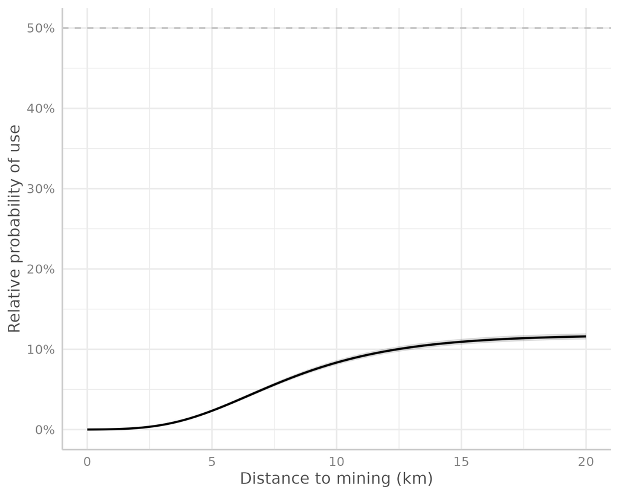

Figure B2. Relative predicted probability of use of areas as a function of the distance to the mine in Kristineberget in calving. Areas close to the mine are avoided up to ca. 10 km.

# 11 Figure B3: Impacts of wind power on habitat selection in calving

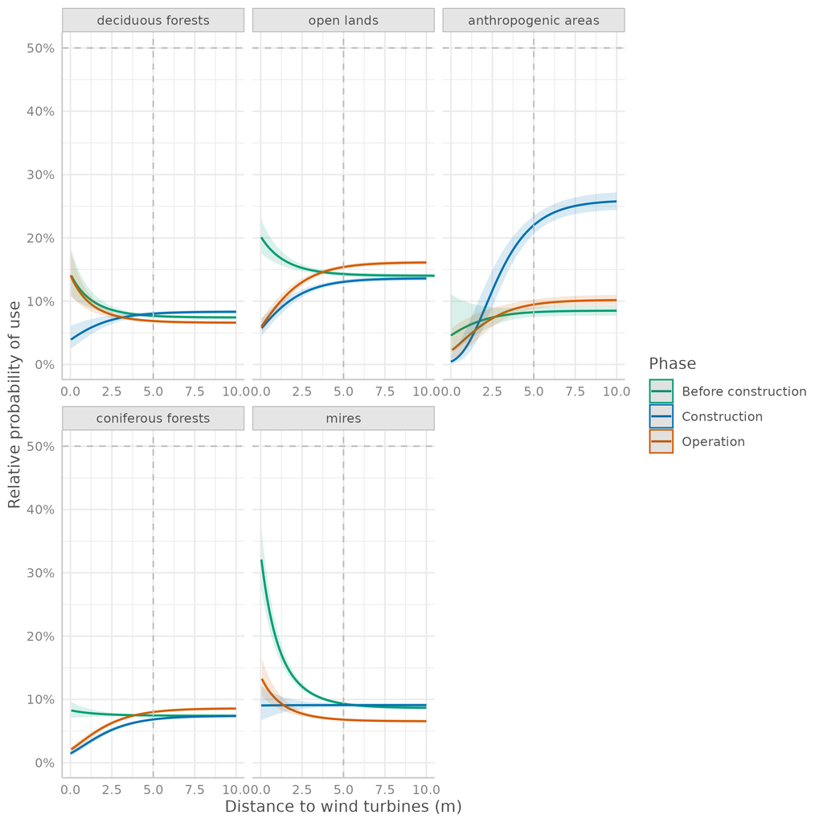

Figure B3. Relative predicted probability of use of areas as a function of the distance to the nearest wind turbine in calving, using Ytterberg wind park as a reference.

# 12 Figure B4: Predicted habitat suitability in calving

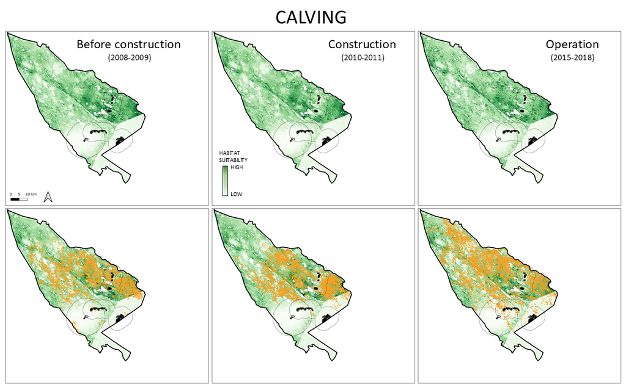

Figure B4. Predicted habitat suitability for reindeer in calving before the construction (left), during the construction (center), and during operation of the wind power plants (right). The top row shows the habitat suitability, in a gradient from 0 (white) to 1 (green), and shows the location of the wind turbines and the mine. It also highlights a buffer of 5 km around the wind power plants and 10 km around the mine, just as a reference for interpretation. The bottom row shows the GPS data for each phase superimposed over the habitat suitabiltiy predictions.

# 13 Figure B5: Impacts of mining on habitat selection in summer

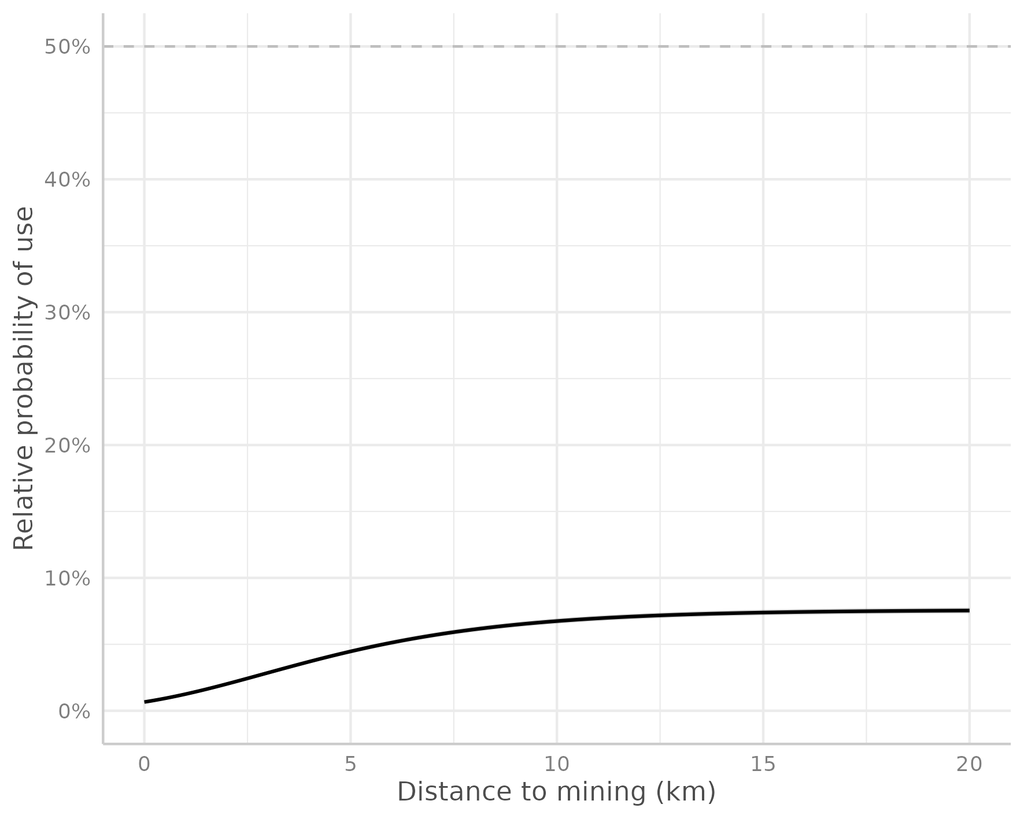

Figure B5. Relative predicted probability of use of areas as a function of the distance to the mine in Kristineberget in summer. Areas close to the mine are avoided up to ca. 10 km.

# 14 Figure B6: Impacts of wind power on habitat selection in summer

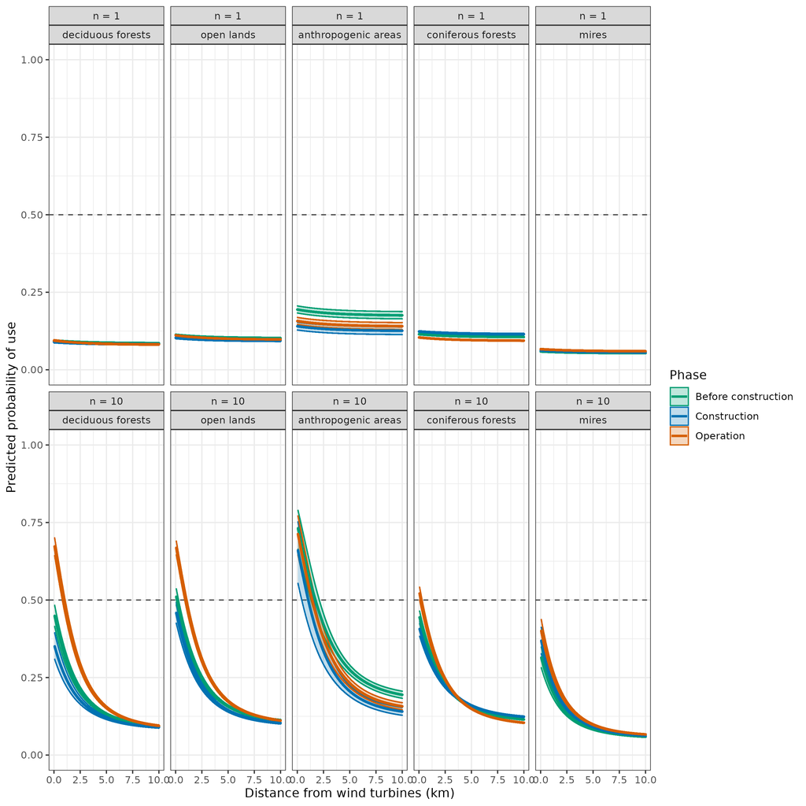

Figure B6. Relative predicted probability of use of areas versus the distance to the nearest wind turbine in summer, using Ytterberg wind park as a reference. Top row shows the (hypothetical) prediction if the wind park was composed only by n = 1 wind turbine - a small impact. The bottom row shows a cumulative impact of n = 10 wind turbines, which gets much larger.

# 15 Figure B7: Predicted habitat suitability in summer

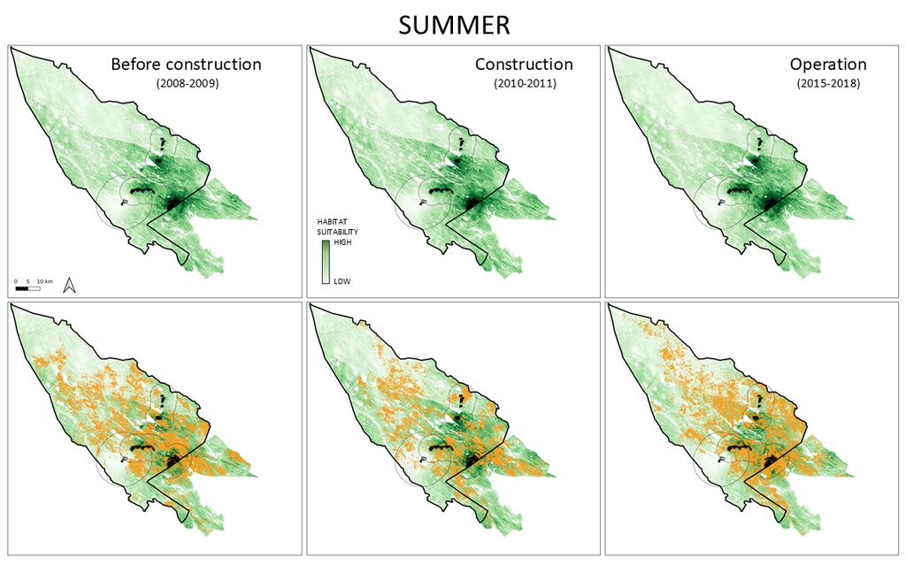

Figure B7. Predicted habitat suitability for reindeer in summer before the construction (left), during the construction (center), and during operation of the wind power plants (right). The top row shows the habitat suitability, in a gradient from 0 (white) to 1 (green), and shows the location of the wind turbines and the mine. It also highlights a buffer of 5 km around the wind power plants and 10 km around the mine, just as a reference for interpretation. The bottom row shows the GPS data for each phase superimposed over the habitat suitabiltiy predictions.

# 16 Figure B8: Impacts of mining on habitat selection in autumn

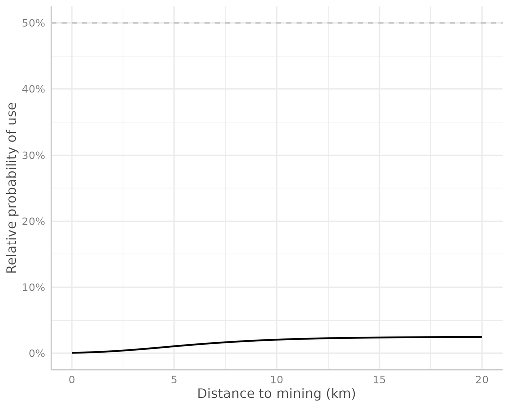

Figure B8. Relative predicted probability of use of areas as a function of the distance to the mine in Kristineberget in autumn. Areas close to the mine are avoided up to ca. 10 km.

# 17 Figure B9: Impacts of wind power on habitat selection in autumn

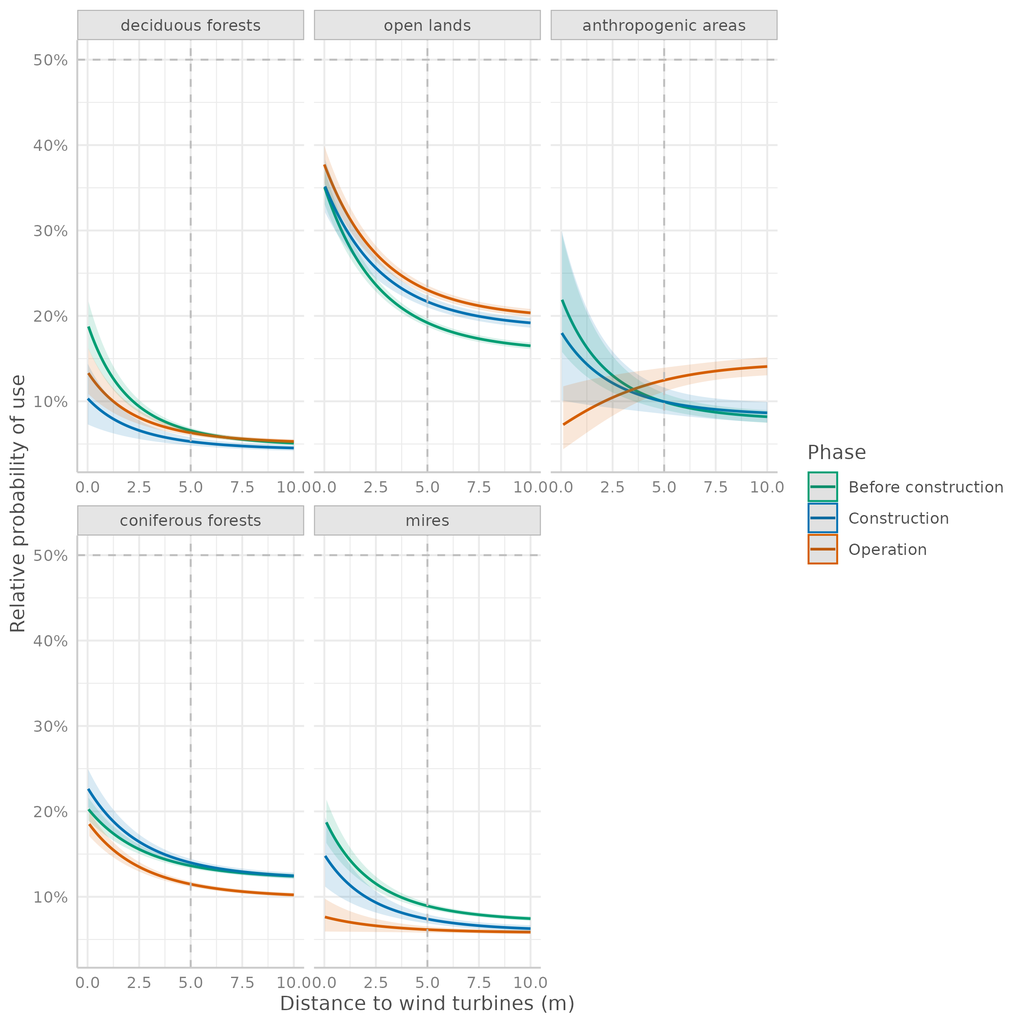

Figure B9. Relative predicted probability of use of areas as a function of the distance to the nearest wind turbine in autumn, using Ytterberg wind park as a reference.

# 18 Figure B10: Predicted habitat suitability in autumn

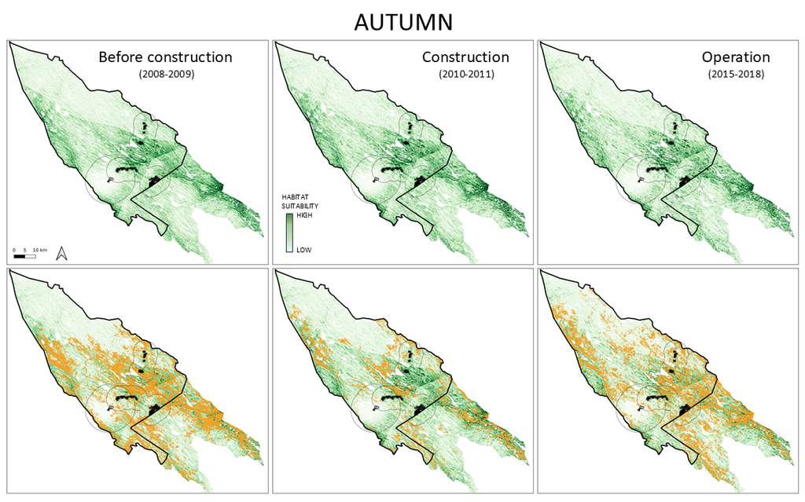

Figure B10. Predicted habitat suitability for reindeer in autumn before the construction (left), during the construction (center), and during operation of the wind power plants (right). The top row shows the habitat suitability, in a gradient from 0 (white) to 1 (green), and shows the location of the wind turbines and the mine. It also highlights a buffer of 5 km around the wind power plants and 10 km around the mine, just as a reference for interpretation. The bottom row shows the GPS data for each phase superimposed over the habitat suitabiltiy predictions.